# Exploring the BRFSS data

Nitesh

8th September

## Synopsys

The Behavioral Risk Factor Surveillance System (BRFSS) is a collaborative project between all of the states in the United States (US) and participating US territories and the Centers for Disease Control and Prevention (CDC). The BRFSS is administered and supported by CDC’s Population Health Surveillance Branch, under the Division of Population Health at the National Center for Chronic Disease Prevention and Health Promotion. BRFSS is an ongoing surveillance system designed to measure behavioral risk factors for the non-institutionalized adult population (18 years of age and older) residing in the US. The BRFSS was initiated in 1984, with 15 states collecting surveillance data on risk behaviors through monthly telephone interviews. Over time, the number of states participating in the survey increased; by 2001, 50 states, the District of Columbia, Puerto Rico, Guam, and the US Virgin Islands were participating in the BRFSS. Today, all 50 states, the District of Columbia, Puerto Rico, and Guam collect data annually and American Samoa, Federated States of Micronesia, and Palau collect survey data over a limited point- in-time (usually one to three months). In this document, the term “state” is used to refer to all areas participating in BRFSS, including the District of Columbia, Guam, and the Commonwealth of Puerto Rico.

Key features of the study :

- The following study is meant for those US states participating in BRFSS.
- The observations made in this study can only be generalized to the 53 states in US.The data is randomly sampled as random phone calls were made to collect the data and hence the dataset is generalizable to the population of US only.
- Research question 1 and 3 don’t show any causal link between variables while question 2 does tend to show some causal link but the casuality cannot be assured.
- The data can be considered biasless as the data was collected over telephone and not face to face. Although there were some data which were misinterpreted and entered incorrectly but that is human error and cannot be considered as biasing.

## Setup

### Load packages

```r
library(ggplot2)
library(dplyr)
```

### Load data

Firstly the `file.exists()` function checks wether the required dataset i.e. `brfss2013.Rdata` is present in the current working directory or not. If the file is not found in that directory, the required file is downloaded from the given URL. Next the dataset is loaded into the R workspace for analysis.

```r
if(!file.exists("brfss2013.RData"))
{
    url <- "https://d3c33hcgiwev3.cloudfront.net/_384b2d9eda4b29131fb681b243a7767d_brfss2013.RData?Expires=1473379200&Signature=Jl0XCES-dsS7knYIywta3bIoDTORqG3Mph4BqtqjygtWLAMfZDJhDkRIls~6hGO7Qewgg2tur7Q1i6ecMvBr5MmmdSQM9b52WhtkFrhNHI8lmobLUa~ycNdphoGaXm5yX2rQBKdmWpFhG5Gr5TJIXokeU6k1tYZ0NHNzmb7NT9Q_&Key-Pair-Id=APKAJLTNE6QMUY6HBC5A"
    download.file(url,"brfss2013.Rdata",method=curl)
}
load("brfss2013.RData")
```

## Part 1: Data

### Studying the data

```r
#Reading column names
names(brfss2013)
```

```
##   [1] "X_state"   "fmonth"    "idate"     "imonth"    "iday"
##   [6] "iyear"     "dispcode"  "seqno"     "X_psu"     "ctelenum"
##  [11] "pvtresd1"  "colghous"  "stateres"  "cellfon3"  "ladult"
##  [16] "numadult"  "nummen"    "numwomen"  "genhlth"   "physhlth"
##  [21] "menthlth"  "poorhlth"  "hlthpln1"  "persdoc2"  "medcost"
##  [26] "checkup1"  "sleptim1"  "bphigh4"   "bpmeds"    "bloodcho"
##  [31] "cholchk"   "toldhi2"   "cvdinfr4"  "cvdcrhd4"  "cvdstrk3"
##  [36] "asthma3"   "asthnow"   "chcscncr"  "chcocncr"  "chccopd1"
##  [41] "havarth3"  "addepev2"  "chckidny"  "diabete3"  "veteran3"
##  [46] "marital"   "children"  "educa"     "employ1"   "income2"
##  [51] "weight2"   "height3"   "numhhol2"  "numphon2"  "cpdemo1"
##  [56] "cpdemo4"   "internet"  "renthom1"  "sex"       "pregnant"
##  [61] "qlactlm2"  "useequip"  "blind"     "decide"    "diffwalk"
##  [66] "diffdres"  "diffalon"  "smoke100"  "smokday2"  "stopsmk2"
##  [71] "lastsmk2"  "usenow3"   "alcday5"   "avedrnk2"  "drnk3ge5"
```

[output cut: 51 more lines]

Different states for which the data has been collected

```r
unique(brfss2013$X_state)
```

```
##  [1] Alabama              Alaska               Arizona
##  [4] Arkansas             California           Colorado
##  [7] Connecticut          Delaware             District of Columbia
## [10] Florida              80                   Georgia
## [13] Hawaii               Idaho                Illinois
## [16] Indiana              Iowa                 Kansas
## [19] Kentucky             Louisiana            Maine
## [22] Maryland             Massachusetts        Michigan
## [25] 0                    Minnesota            Mississippi
## [28] Missouri             Montana              Nebraska
## [31] Nevada               New Hampshire        New Jersey
## [34] New Mexico           New York             North Carolina
## [37] North Dakota         Ohio                 Oklahoma
## [40] Oregon               Pennsylvania         Rhode Island
## [43] South Carolina       South Dakota         Tennessee
## [46] Texas                Utah                 Vermont
## [49] Virginia             Washington           West Virginia
## [52] Wisconsin            Wyoming              Guam
## [55] Puerto Rico
## 55 Levels: 0 Alabama Alaska Arizona Arkansas California ... 80
```

It can be seen that there are 2 states having invalid names 80 and 0. The row corresponding to these values must be removed, thus removing the required rows

```r
brfss2013 <- brfss2013[brfss2013$X_state != '80',]
brfss2013 <- brfss2013[brfss2013$X_state != '0',]
```

Years for which the data has been collected

```r
unique(brfss2013$iyear)
```

```
## [1] 2013 2014 <NA>
## Levels: 2013 2014
```

Calculating the number of NA values in each column

```r
colSums(is.na(brfss2013))
```

```
##   X_state    fmonth     idate    imonth      iday     iyear  dispcode
##         0         2         1         1         1         3         3
##     seqno     X_psu  ctelenum  pvtresd1  colghous  stateres  cellfon3
##         2         1        39    131634    491729    131640    135149
##    ladult  numadult    nummen  numwomen   genhlth  physhlth  menthlth
##    491735    131649    131649    131649      1983     10956      8626
##  poorhlth  hlthpln1  persdoc2   medcost  checkup1  sleptim1   bphigh4
##    243152      1902      1799      1219      6303      7386      1418
##    bpmeds  bloodcho   cholchk   toldhi2  cvdinfr4  cvdcrhd4  cvdstrk3
##    293199      9008     73176     71660      2586      4422      1466
##   asthma3   asthnow  chcscncr  chcocncr  chccopd1  havarth3  addepev2
##      1558    426434      1308      1147      2723      2968      2287
##  chckidny  diabete3  veteran3   marital  children     educa   employ1
##      1719       831       745      3418      2272      2273      3384
##   income2   weight2   height3  numhhol2  numphon2   cpdemo1   cpdemo4
##     71424         0      7621    134363    475601    135079    227077
##  internet  renthom1       sex  pregnant  qlactlm2  useequip     blind
##      4924      8446         5    414788     11327     10315     11077
##    decide  diffwalk  diffdres  diffalon  smoke100  smokday2  stopsmk2
##     12988     12762     12120     13348     14918    276981    415419
##  lastsmk2   usenow3   alcday5  avedrnk2  drnk3ge5  maxdrnks  fruitju1
##    354495     14016     19642    260588    260442    264956     36206
##    fruit1   fvbeans   fvgreen   fvorang  vegetab1  exerany2  exract11
##     33796     37490     35155     36561     38945     34027    160946
##  exeroft1  exerhmm1  exract21  exeroft2  exerhmm2  strength  lmtjoin3
##    164163    168393    166037    278231    283649     39817    338393
##  arthdis2  arthsocl  joinpain  seatbelt  flushot6  flshtmy2   tetanus
##    341267    338576    344063     38933     40452    297163     83346
##  pneuvac3   hivtst6  hivtstd3  whrtst10  pdiabtst  prediab1  diabage2
##     84500     54591    387290    362809    267195    257911         0
##   insulin  bldsugar  feetchk2  doctdiab  chkhemo3   feetchk   eyeexam
##    455378    456005    456495         0    458718    457123    455968
##   diabeye   diabedu  painact2  qlmentl2  qlstres2   qlhlth2  medicare
##    455879    455485    491285    491282    491286    491308    178789
##  hlthcvrg  delaymed  dlyother  nocov121  lstcovrg  drvisits  medscost
##         0    144719         0    182110    455019    154150    142623
##  carercvd  medbills  ssbsugar  ssbfrut2  wtchsalt  longwtch  dradvise
##    153214    144295    388578    388801    363746    421172    363786
##  asthmage  asattack  aservist  asdrvist  asrchkup  asactlim  asymptom
##    490282    490771    491254    491271    490796    490847    490806
```

[output cut: 41 more lines]

```
##         9         7        10         8     28700     30163     28701
##  X_veglt1   X_frt16   X_veg23 X_fruitex X_vegetex X_totinda  metvl11_
##     30162         8        10         8        10     34032    175067
##  metvl21_   maxvo2_     fc60_  actin11_  actin21_   padur1_   padur2_
##    183997      4727      4728    177752    186561    168394    283650
##  pafreq1_  pafreq2_ X_minac11 X_minac21  strfreq_  pamiss1_  pamin11_
##    164167    278232    170037    174654     39822     34030    186261
##  pamin21_   pa1min_  pavig11_  pavig21_  pa1vigm_  X_pacat1 X_paindx1
##    193750    167959    181419    189963         0     76876     67569
## X_pa150r2 X_pa300r2 X_pa30021 X_pastrng  X_parec1 X_pastae1 X_lmtact1
##     67568     76876     76875     39823     71484     71487     14746
## X_lmtwrk1 X_lmtscl1 X_rfseat2 X_rfseat3 X_flshot6 X_pneumo2 X_aidtst3
##     17620     14929     38941     38939    343077    349052     54593
##   X_age80
##         9
```

Removing columns where more than 50% of the data contain NA values as those columns hardly provides any information regarding that particular variable

```r
brfss2013 <- brfss2013[,colSums(is.na(brfss2013))<0.5*nrow(brfss2013)]
```

Now the dataset is ready for further study.

## Part 2: Research questions

**Research quesion 2:** Is there a distinct difference in the health of smokers to non-smokers ?

**Research quesion 3:** How many adults are satisfied with the care received ?

## Part 3: Exploratory data analysis

**Research quesion 1:**

This question provides answer to the sleeping habits in different states of US which might help is studying about psycological state of any subject under consideration.

Creating a new dataset named `sleepingHours` which stores the information about sleeping hours for each state. Another data frame named `stateCount` holds the count each state present in the `brfss2013` dataset.

```r
sleepingHours <- aggregate(brfss2013$sleptim1,by = list(brfss2013$X_state),sum,na.rm=TRUE)
stateCount <- as.data.frame(table(brfss2013$X_state))
sleepingHours <-merge(sleepingHours,stateCount,by.x='Group.1',by.y = 'Var1')
sleepingHours$averageTime<-sleepingHours$x/sleepingHours$Freq
```

Plot showing average sleeping hours for adults of each state

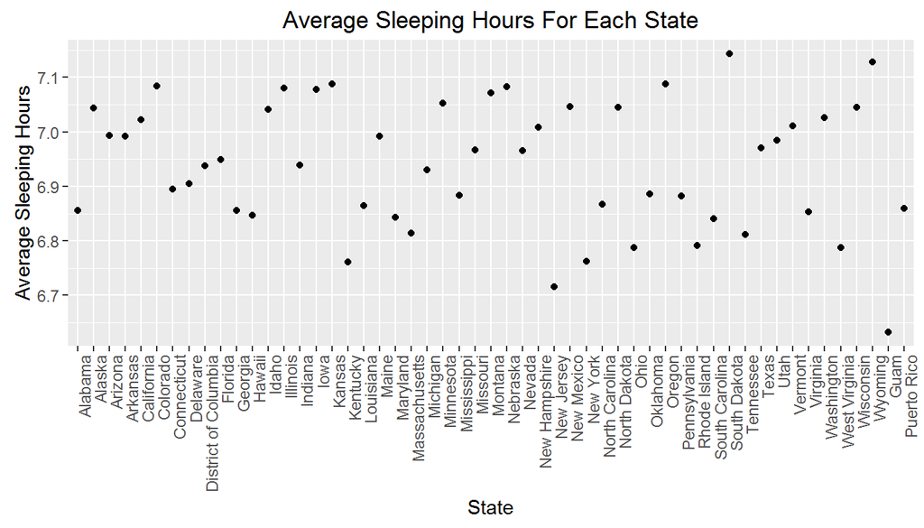

```r
ggplot(sleepingHours,aes(Group.1,averageTime)) + geom_point() + theme(axis.text.x = element_text(angle = 90, hjust = 1)) + xlab("State") + ylab("Average Sleeping Hours") + ggtitle("Average Sleeping Hours For Each State")
```

State with highest average sleeping hour

```r
sleepingHours[sleepingHours$averageTime==max(sleepingHours$averageTime),'Group.1']
```

[output not shown]

**Research quesion 2:**

Tobacco is well known for its health consequences, hence it is necessary to undestand the impact of ciggerate on the health of its consumers.

Plot comparing the health of the people who have smoked atleast 100 ciggerates vs those who have not.

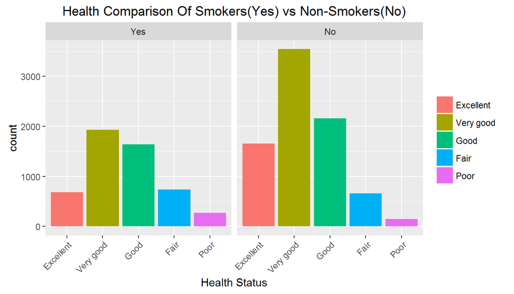

```r
ggplot(na.omit(brfss2013),aes(genhlth,fill = genhlth)) + geom_bar() + facet_grid(.~smoke100) + xlab("Health Status") + ggtitle("Health Comparison Of Smokers(Yes) vs Non-Smokers(No)") + theme(axis.text.x = element_text(angle = 45, hjust = 1),legend.title = element_blank())
```

The plot clearly shows that people who have smoked atleast 100 ciggerates have worse health conditions than those who have smoked less than 100 ciggerates.

**Research quesion 3:**

Review provided by each user gives us a nice picture of wether they are satisfied with the care reveived. Regular evaluation in reviews help in providing better services and maintaining the right standard.

Based on different user reviews, plotting the satisfaction with the care received

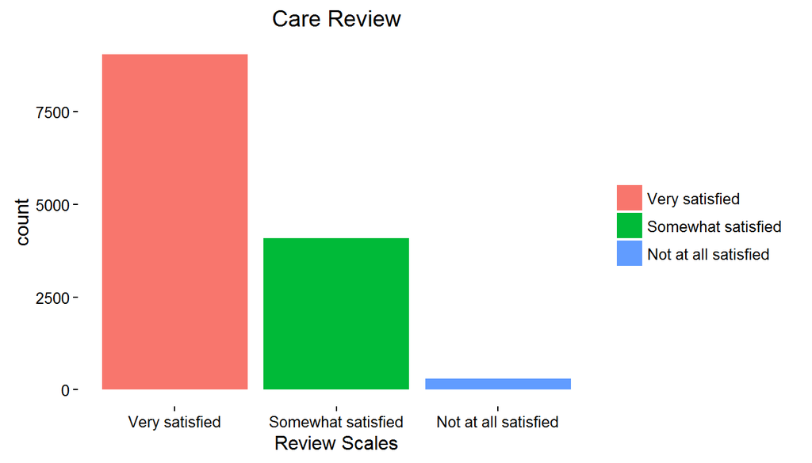

```r
ggplot(na.omit(brfss2013),aes(carercvd,fill=carercvd)) + geom_bar() + theme_classic() + ggtitle("Care Review") + xlab("Review Scales") + theme(legend.title=element_blank())
```

Thus here it can be seen that most of the users are very satisfied with the care received. Verifying the above plot with actual number of user reviews

```r
summary(na.omit(brfss2013$carercvd))
```

```
##       Very satisfied   Somewhat satisfied Not at all satisfied
##               227880                98644                12035
```